# IAV Key Exposures

jonasalexandersteiner

2026-01-29

# Logistic regression of key factors in binary PLSR

This report presents summary results and visualizations for a logistic regression model for IAV status in pig herds:

- Top 25 predictors by PLS-DA VIP were identified (husbandry subset).
- Univariate logistic regressions were computed for these predictors to assess their invidual influence on IAV detection.
- The final 4 predictors were chosen based on greatest VIP scores, then manually screened for biological plausibility. Variables reflecting intensive farming, missingness, or non-independence/confounding were excluded (see column ‘exclusion_due_to_biological_plausibility’ in tables).
- Multivariable logistic regression was performed with diagnostic checks and transparent reporting.
- Calibration of the model was assessed using the Hosmer-Lemeshow test and a calibration plot.

## Husbandry Subset Model

### Model Sample Size

N (Husbandry model used): 100

Top 25 by VIP with exclusion rationale

| variable | VIP | exclusion_due_to_biological_plausibility |
| --- | --- | --- |
| contact_bird_in_stable_TRUE | 3.37 |  |
| ai_airspace_with_other_agegroup_2 | 3.23 | Confounding: proxy for intensive farming |
| ai_airspace_with_other_agegroup_1 | 2.15 | Confounding: proxy for intensive farming |
| production_cycle_3 | 2.04 | Class imbalance: likely spurious finding |
| cleaning_weaner_stable_FALSE | 2.04 | Confounding: proxy for intensive farming |
| number_suckling_piglets | 1.95 | No effect in logistic regression (exclude) |
| caretaker_entry_ppe_only_TRUE | 1.86 | Confounding: proxy for intensive farming |
| bird_nests_FALSE | 1.84 | Confounding: proxy for intensive farming |
| farrowing_airspace_with_other_agegroup_2 | 1.79 | Confounding: proxy for intensive farming |
| cross_fostering_farrowing_stable_3 | 1.78 |  |
| weaners_airspace_with_other_agegroup_3 | 1.70 |  |
| fattening_pigs_airspace_with_other_agegroup_4 | 1.68 | Confounding: proxy for intensive farming |
| production_cycle_2 | 1.59 | Class imbalance: likely spurious finding |
| proximity_to_other_poultry_herd_FALSE | 1.57 | Confounding: proxy for intensive farming |
| farrowing_airspace_with_other_agegroup_3 | 1.52 | Confounding: proxy for intensive farming |
| outside_area_contact_wild_boars_FALSE | 1.46 | Confounding: proxy for intensive farming |
| number_weaners | 1.42 | No effect in logistic regression (exclude) |
| separation_quarantine_area_2 | 1.35 | Confounding: proxy for intensive farming |
| cleaning_shipment_area_TRUE | 1.29 | Confounding: proxy for intensive farming |
| cattle_closeby_FALSE | 1.28 | Confounding: proxy for intensive farming |
| outside_area_contact_poultry_TRUE | 1.27 | Confounding: proxy for intensive farming |
| herdsize | 1.26 | No effect in logistic regression (exclude) |
| caretaker_ppe_washing_interval_FALSE | 1.24 | Confounding: proxy for intensive farming |
| mode_stable_occupation_ai_centre_TRUE | 1.24 | Confounding: proxy for intensive farming |
| proximity_to_other_pig_herd_TRUE | 1.21 |  |

### Model Coefficients

**Logistic regression coefficients, standard errors, and z-values. Model includes final 4 predictors.**

Coefficients (Husbandry Model)

| Predictor | Estimate | Std. Error | z value |
| --- | --- | --- | --- |
| (Intercept) | -2.174 | 0.588 | -3.696 |
| contact_bird_in_stable_TRUE | 1.506 | 0.479 | 3.142 |
| cross_fostering_farrowing_stable_3 | 0.260 | 0.554 | 0.470 |
| weaners_airspace_with_other_agegroup_3 | 0.868 | 0.486 | 1.786 |
| proximity_to_other_pig_herd_TRUE | 0.529 | 0.514 | 1.029 |

### Odds Ratios and Confidence Intervals

Odds Ratios & 95% CI (Husbandry Model)

| Predictor | Odds Ratio | 2.5 % | 97.5 % |
| --- | --- | --- | --- |
| (Intercept) | 0.114 | 0.032 | 0.332 |
| contact_bird_in_stable_TRUE | 4.510 | 1.806 | 11.990 |
| cross_fostering_farrowing_stable_3 | 1.297 | 0.429 | 3.842 |
| weaners_airspace_with_other_agegroup_3 | 2.382 | 0.938 | 6.400 |
| proximity_to_other_pig_herd_TRUE | 1.698 | 0.632 | 4.830 |

### Diagnostics Overview

- **Pseudo-R² (McFadden):** 0.121 — > 0.2 = reasonable; lower = weak fit.  
  Model fit is weak.
- **AUC (ROC Curve):** 0.726 — > 0.7 = acceptable, > 0.8 = good.  
  Discrimination is acceptable.

### Multicollinearity

**Variance Inflation Factor (VIF) for each predictor. VIF > 5 signals multicollinearity.**

Variance Inflation Factor (Husbandry Model)

| Predictor | VIF |
| --- | --- |
| contact_bird_in_stable_TRUE | 1.10 |
| cross_fostering_farrowing_stable_3 | 1.11 |
| weaners_airspace_with_other_agegroup_3 | 1.12 |
| proximity_to_other_pig_herd_TRUE | 1.06 |

### Top 5 Influential Observations

**Cook’s Distance for the top 5 most influential points; high values may indicate outliers.**

Top 5 Cook’s Distance Values (Husbandry Model)

| Observation | Cook_Distance |
| --- | --- |
| 11 | 0.036 |
| 15 | 0.036 |
| 53 | 0.036 |
| 76 | 0.036 |
| 86 | 0.036 |

### Visualizations

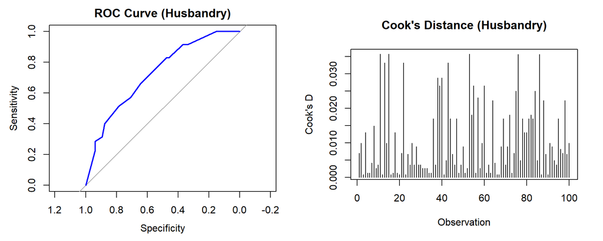

### Calibration

**Calibration of model predictions was assessed by the Hosmer-Lemeshow test and a calibration plot.**

**Hosmer-Lemeshow Test:**  
Chi-squared = 3.2 , df = 7 , p-value = 0.866  
A p-value > 0.05 suggests good calibration.

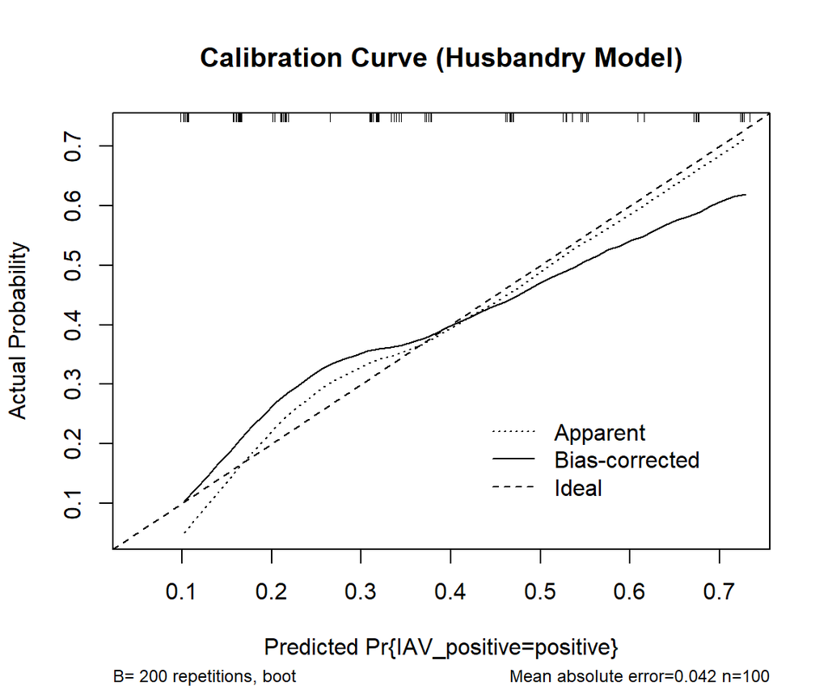

n=100 Mean absolute error=0.042 Mean squared error=0.00257 0.9 Quantile of absolute error=0.087

## Interpretation Notes

- **Exploratory Analysis:** No p-values or statistical significance are interpreted for selection, but all effect sizes and CIs are transparently reported.
- **Biological plausibility exclusion:** See the ‘exclusion_due_to_biological_plausibility’ column in tables for rationale for exclusion.
- **Model Fit:** Consider pseudo-R² and AUC for overall model quality.
- **Calibration:** Hosmer-Lemeshow and calibration curve should be checked for model reliability.
- **Multicollinearity:** High VIFs may require model simplification.
- **Influential Points:** Consider sensitivity analysis excluding high Cook’s D observations.